# Twitter's Climate Tide: An Analysis of Tweets About Climate Change

## December 21, 2020

[figure not shown]

Impacts of Climate Change (https://climate.nasa.gov/effects/)

# Introduction

In this project I will be looking at data from Twitter, specifically tweets about [climate change](https://climate.nasa.gov) collected by George Washing University (GWU) from 2017 to 2019 with most data from 2018. I will be looking at things like what was the most common things talked about in relation to climate and what the sentiment was for the all these tweets, a specific time, etc. Then, I will predict the sentiment of a tweet using a variety of machine learning algorithms.

# Getting started

### The libraries I will be using are: [matplotlib](https://matplotlib.org/index.html#), [pandas](https://pandas.pydata.org), [spaCy](https://spacy.io), [seaborn](https://seaborn.pydata.org), [Gensim](https://radimrehurek.com/gensim/), [wordcloud](http://amueller.github.io/word_cloud/), [scikit-learn](https://scikit-learn.org/stable/), and [VADER](https://github.com/cjhutto/vaderSentiment).

### Installations

```python
# Wordcloud
#!pip install wordcloud

# Seaborn
#!pip install seaborn --upgrade
# Gensim
#!pip install --upgrade gensim

# Spacy
#!pip install -U spacy
#!pip install -U spacy-lookups-data
#!python -m spacy download en_core_web_sm

# VADER
#!pip install vaderSentiment
```

### Import everything needed

```python
# Basics and essentials
import pandas as pd
import string
import re
import datetime
import random

# Visualization
import seaborn as sns
import matplotlib.pyplot as plt
from wordcloud import WordCloud

# Natural language processing and machine learning
import spacy
import gensim
# Vader
from vaderSentiment.vaderSentiment import SentimentIntensityAnalyzer
# Scikit-learn
from sklearn.feature_extraction.text import CountVectorizer
from sklearn.feature_extraction.text import TfidfTransformer
from sklearn.naive_bayes import MultinomialNB
from sklearn.ensemble import RandomForestClassifier
from sklearn.pipeline import Pipeline
from sklearn.metrics import accuracy_score
from sklearn.svm import SVC
```

# Data Collection

For my data, I used a GWU dataset of climate change tweets that were collected from 2017-2019 (Littman, Justin; Wrubel, Laura, 2019, "Climate Change Tweets Ids", https://doi.org/10.7910/DVN/5QCCUU, Harvard Dataverse, V1). I downloaded my sample from GWU which makes picking your criteria for the tweets simple. You can make your own data set from all 40 million right [here](https://tweetsets.library.gwu.edu/datasets).

Here is a link to my exact sample: http://tweetsets.library.gwu.edu/dataset/723265b8. You can also see my sample in the form of the tweet ids in my GitHub repo: [arjungandhi521/arjungandhi521.github.io/public_data/tweets_ids_125k.txt](https://github.com/arjungandhi521/arjungandhi521.github.io/blob/main/public_data/tweet_ids_125k.txt).

I sampled 125,000 of the 40 million tweets. The CSV I use directly below is private because of Twitter policy that one should not publish large amounts of tweets but that people in academics and such can go ahead and publish the tweet ids. As stated in the GWU link the data is from betewen September 21, 2017 and May 17, 2019 and they had a gap in data collection from January 7, 2019 to April 17, 2019.

I chose to exclude retweets and this sample ranges from late 2017 to mid-2019 which is the full collection time. I excluded retweets because even though a tweet with 1 billion RTs may have high influence on Twitter, having it n times in the dataset is not really going to add to my understanding of the language. I still have access to the favorites and retweets data which I will use later on.

To convert each tweet ID into the actual tweet data I am using Hydrator (Hydrator [Computer Software]. Retrieved from https://github.com/docnow/hydrator). From this repo, I downloaded [version 0.0.13 of the app](https://github.com/DocNow/hydrator/releases/tag/v0.0.13). I made a Twitter account to connect my account to Hydrator so that it can use the Twitter API. When you download the sample just pick to download tweet ids on the GWU site or use the tweet ids in my repo. This will be a compressed .txt file (if you get it from GWU). Just unzip it and then upload the file into Hydrator under "Datasets" in the desktop app. Then hit "Add Dataset" and then "Start" and then when its done you can click CSV to get the JSONL as a CSV. When I hydrated the tweets (turned them from tweet ids into tweets you see below), I started with 125,000 ids but the dataframe directly below has less. This is for several reasons including people making their accounts private and deleted tweets and accounts. These tweet ids were put into the dataset before these thing happend.

```python
data = pd.read_csv("./data/tweets_125k.csv")
data
```

|  | coordinates | created_at | hashtags | media | urls | favorite_count | id | in_reply_to_screen_name | in_reply_to_status_id | in_reply_to_user_id | ... | user_followers_count | user_friends_count | user_listed_count | user_location | user_name | user_screen_name.1 | user_statuses_count | user_time_zone | user_urls | user_verified |
| --- | --- | --- | --- | --- | --- | --- | --- | --- | --- | --- | --- | --- | --- | --- | --- | --- | --- | --- | --- | --- | --- |
| 0 | NaN | Tue Dec 11 01:00:00 +0000 2018 | UN cdnpoli ONpoli ABpoli | https://twitter.com/TheRebelTV/status/10722948... | https://www.therebel.media/un-global-warming-m... | 91 | 1072294898588631040 | NaN | NaN | NaN | ... | 207643 | 17379 | 1266 | Canada and the world | Rebel News | RebelNewsOnline | 39345 | NaN | https://www.rebelnews.com | True |
| 1 | NaN | Mon Jan 22 09:49:35 +0000 2018 | NaN | NaN | NaN | 0 | 955376892026093569 | Pontifex | 9.551606e+17 | 5.007043e+08 | ... | 1 | 4 | 0 | United States | Frank | Frank34802901 | 100 | NaN | NaN | False |
| 2 | NaN | Mon Sep 17 04:42:16 +0000 2018 | NaN | NaN | https://truthout.org/articles/national-park-of... | 0 | 1041547863795224576 | NaN | NaN | NaN | ... | 2062 | 2383 | 99 | USA | OurRevolution | LeftysUnite | 50076 | NaN | NaN | False |
| 3 | NaN | Sat Aug 04 13:02:13 +0000 2018 | Spain Portugal climatechange globalwarming Hea... | NaN | https://news.sky.com/story/live-scorching-satu... | 1 | 1025728615399469058 | NaN | NaN | NaN | ... | 25 | 24 | 1 | NaN | Steven Hugh | Steven9Hugh | 1402 | NaN | https://stevenhugh.wordpress.com/ | False |
| 4 | NaN | Tue Nov 21 10:17:51 +0000 2017 | Resist FakePresident Dontard GOP NRA War Clima... | NaN | https://twitter.com/mattmfm/status/93272970237... | 0 | 932915956824682496 | NaN | NaN | NaN | ... | 6214 | 6747 | 121 | the beautiful "Jemez" USA | Athoughtz | athoughtz | 155954 | NaN | http://TokTok.com | False |
| ... | ... | ... | ... | ... | ... | ... | ... | ... | ... | ... | ... | ... | ... | ... | ... | ... | ... | ... | ... | ... | ... |
| 91264 | NaN | Sat Apr 27 16:22:49 +0000 2019 | NaN | NaN | NaN | 1 | 1122174270208126978 | bruceanderson | 1.122169e+18 | 8.037439e+07 | ... | 491 | 779 | 9 | Regina | sean osmar | SeanOsmar | 2229 | NaN | NaN | False |
| 91265 | NaN | Sat Apr 27 11:36:03 +0000 2019 | plasticpollution climatechange | NaN | NaN | 0 | 1122102103185547270 | RochdaleCouncil | NaN | 2.052017e+07 | ... | 87 | 177 | 6 | Wandering the Wastelands | Gatt 🇬🇧🇪🇺 | Gatt_ | 2591 | NaN | NaN | False |
| 91266 | NaN | Sat Apr 27 16:23:09 +0000 2019 | NaN | NaN | https://www.usatoday.com/story/news/nation/201... | 0 | 1122174355084062720 | NaN | NaN | NaN | ... | 110 | 644 | 2 | Omaha, Nebraska | Dee Dee | Dee_Dee2018 | 2765 | NaN | NaN | False |
| 91267 | NaN | Sat Apr 27 16:23:07 +0000 2019 | NaN | NaN | NaN | 0 | 1122174343562158081 | NaN | NaN | NaN | ... | 2217 | 1838 | 450 | Vancouver | Bonnie | greenurlifenow | 254477 | NaN | NaN | False |
| 91268 | NaN | Sat Apr 27 16:23:32 +0000 2019 | NaN | NaN | NaN | 0 | 1122174449095270403 | creeker112 | 1.122173e+18 | 1.108134e+18 | ... | 18 | 327 | 0 | Gainesville, FL | Oliver #BLM | obliqueObloquy | 492 | NaN | NaN | False |

91269 rows × 34 columns

As you can see, there are many columns. Most of these won't help me so many will have to go. Others need some fixing up to be useful like the date and time strings need to be date objects.

# Data Wrangling

The data set has lots of data that is not needed for this analysis. The data set is multilingual and so to make things simple for this project I will just drop the non-English tweets.

There are lots of extranenous columns that are not relavent to this project so I just dropped them. These included geolocation data that was often missing, user information, and extranenous data about a tweet like time zone and lanague (since I drop all non-English ones to begin). These include things like user specifics like their profile details and other things like the URL of the tweet.

I followed this tutorial for help with tasks like lemmatization here and for things in the next section (EDA/Data Viz) such as making bags of words and word clouds: https://www.analyticsvidhya.com/blog/2020/04/beginners-guide-exploratory-data-analysis-text-data/

## Remove non-English tweets and extraneous columns.

```python
# Remove non-English tweets from the data set
data = data[data["lang"] == "en"]

# Drop all the unneeded columns from the data set
cols_to_delete = ["user_urls", "user_statuses_count", "coordinates", "user_name", "in_reply_to_status_id",
                  "in_reply_to_user_id", "user_time_zone", "urls", "lang", "media", "source",
                  "retweet_screen_name", "retweet_id", "possibly_sensitive", "tweet_url",
                  "user_default_profile_image", "user_friends_count", "user_verified", "user_location",
                   "in_reply_to_screen_name", "user_screen_name.1",
                  "user_favourites_count", "user_listed_count", "user_created_at", "user_description", "place",
                 "user_followers_count", "hashtags"]

data = data.drop(columns=cols_to_delete)

# Swap the index column from 0...n to the tweet ID and rename the column from id to tweetID and rename to clarify
# column meaning
data = data.rename(columns={"id": "tweetID", "created_at": "date/time", "user_screen_name": "tweeter"})
data = data.set_index('tweetID')
data
```

| tweetID | date/time | favorite_count | retweet_count | text | tweeter |
| --- | --- | --- | --- | --- | --- |
| 1072294898588631040 | Tue Dec 11 01:00:00 +0000 2018 | 91 | 55 | .@TheRebelTV goes to two different #UN confere... | RebelNewsOnline |
| 955376892026093569 | Mon Jan 22 09:49:35 +0000 2018 | 0 | 0 | @Pontifex Prayers to God the one &amp; only t... | Frank34802901 |
| 1025728615399469058 | Sat Aug 04 13:02:13 +0000 2018 | 1 | 0 | Red alert in #Spain and #Portugal as Europe ne... | Steven9Hugh |
| 932915956824682496 | Tue Nov 21 10:17:51 +0000 2017 | 0 | 0 | Trump /GOP are the swamp #Resist #FakePresiden... | athoughtz |
| 1041547806622797824 | Mon Sep 17 04:42:02 +0000 2018 | 3 | 1 | Study: Green Buildings Save $6.7 Billion in #H... | IndiaGreenBldg |
| ... | ... | ... | ... | ... | ... |
| 1122174270208126978 | Sat Apr 27 16:22:49 +0000 2019 | 1 | 0 | @bruceanderson What's the issue? He agrees cli... | SeanOsmar |
| 1122102103185547270 | Sat Apr 27 11:36:03 +0000 2019 | 0 | 0 | @RochdaleCouncil need to start accepting ALL p... | Gatt_ |
| 1122174355084062720 | Sat Apr 27 16:23:09 +0000 2019 | 0 | 0 | Climate change, global warming: Grandparents t... | Dee_Dee2018 |
| 1122174343562158081 | Sat Apr 27 16:23:07 +0000 2019 | 0 | 0 | Of course, each person contributes to the stat... | greenurlifenow |
| 1122174449095270403 | Sat Apr 27 16:23:32 +0000 2019 | 0 | 0 | @creeker112 @IlhanMN Well, capitalism is behin... | obliqueObloquy |

83624 rows × 5 columns

## Combine the likes and retweets for total interaction score.

I will treat both with equal weight in this score for simplicity.

```python
# Combine the number of favorites and retweets for a tweet into an total interactions score
total_interactions = []

for row in data.iterrows():
    tweet = row[1]
    total = tweet["retweet_count"] + tweet["favorite_count"]
    total_interactions.append(total)

# Swap out the current RT and favorites columns for the total interactions columns
data["total_interactions"] = total_interactions
data = data.drop(columns=["retweet_count", "favorite_count"])
data.head()
```

| tweetID | date/time | text | tweeter | total_interactions |
| --- | --- | --- | --- | --- |
| 1072294898588631040 | Tue Dec 11 01:00:00 +0000 2018 | .@TheRebelTV goes to two different #UN confere... | RebelNewsOnline | 146 |
| 955376892026093569 | Mon Jan 22 09:49:35 +0000 2018 | @Pontifex Prayers to God the one &amp; only t... | Frank34802901 | 0 |
| 1025728615399469058 | Sat Aug 04 13:02:13 +0000 2018 | Red alert in #Spain and #Portugal as Europe ne... | Steven9Hugh | 1 |
| 932915956824682496 | Tue Nov 21 10:17:51 +0000 2017 | Trump /GOP are the swamp #Resist #FakePresiden... | athoughtz | 0 |
| 1041547806622797824 | Mon Sep 17 04:42:02 +0000 2018 | Study: Green Buildings Save $6.7 Billion in #H... | IndiaGreenBldg | 4 |

## Convert the time/date strings into date objects

I do this because these are much easier to use and more usefulf for analysis later on.

```python
# Convert the dates time strings into datetime objects
dates = []

# Matching this text
# Mon Jan 22 09:49:35 +0000 2018
regex = re.compile(r"(\w{3}) (\w{3}) (\d\d) (\d\d:\d\d:\d\d) \+(0{4}) (\d{4})")

# Given a string of a month return the corresponding integer for that month i.e. Jan == 1
def numerize(str):
    month = str.lower()
    if (month == "jan"): return 1
    elif (month == "feb"): return 2
    elif (month == "mar"): return 3
    elif (month == "apr"): return 4
    elif (month == "may"): return 5
    elif (month == "jun"): return 6
    elif (month == "jul"): return 7
    elif (month == "aug"): return 8
    elif (month == "sep"): return 9
    elif (month == "oct"): return 10
    elif (month == "nov"): return 11
    elif (month == "dec"): return 12

for row in data.iterrows():
    dt = row[1]["date/time"]
    matches = re.search(regex, dt)
    groups = matches.groups()
    month = numerize(groups[1])
    d = datetime.date(int(groups[5]), month, int(groups[2]))
    dates.append(d)

data = data.drop(columns=["date/time"])
data["date_tweeted"] = dates
data.head()
```

| tweetID | text | tweeter | total_interactions | date_tweeted |
| --- | --- | --- | --- | --- |
| 1072294898588631040 | .@TheRebelTV goes to two different #UN confere... | RebelNewsOnline | 146 | 2018-12-11 |
| 955376892026093569 | @Pontifex Prayers to God the one &amp; only t... | Frank34802901 | 0 | 2018-01-22 |
| 1025728615399469058 | Red alert in #Spain and #Portugal as Europe ne... | Steven9Hugh | 1 | 2018-08-04 |
| 932915956824682496 | Trump /GOP are the swamp #Resist #FakePresiden... | athoughtz | 0 | 2017-11-21 |
| 1041547806622797824 | Study: Green Buildings Save $6.7 Billion in #H... | IndiaGreenBldg | 4 | 2018-09-17 |

## Prepare the tweets for sentiment analysis

### Remove links

Links do not add meaning to a tweet when analyzing their sentiment and visualizing what words people say so they are just texual clutter and thus we will delete them with the magic of regular expressions!

```python
linkless = []
regex = re.compile(r"http\S+")

# remove all links from each tweet
for row in data.iterrows():
    txt = row[1]["text"]
    if txt.find("https://t.co"):
        ll = re.sub(regex, "", txt)
        linkless.append(ll)
    else:
        linkless.append(txt)

data["text"] = linkless
data.head()
```

| tweetID | text | tweeter | total_interactions | date_tweeted |
| --- | --- | --- | --- | --- |
| 1072294898588631040 | .@TheRebelTV goes to two different #UN confere... | RebelNewsOnline | 146 | 2018-12-11 |
| 955376892026093569 | @Pontifex Prayers to God the one &amp; only t... | Frank34802901 | 0 | 2018-01-22 |
| 1025728615399469058 | Red alert in #Spain and #Portugal as Europe ne... | Steven9Hugh | 1 | 2018-08-04 |
| 932915956824682496 | Trump /GOP are the swamp #Resist #FakePresiden... | athoughtz | 0 | 2017-11-21 |
| 1041547806622797824 | Study: Green Buildings Save $6.7 Billion in #H... | IndiaGreenBldg | 4 | 2018-09-17 |

### "Preprocess" the tweets

I will use Gensim to clean up the text of the tweet. It will get rid of long and short words that do not add meaning to a tweet. This function call will also do things like make the tweets all lower case so they are treated as the same words later no matter what their case usage is. By this I mean that semantically WORD is the same as word is the same as WOrd. It will also tokenize the tweet but what does that mean you ask?

#### Tokenization

Tokenization a fundemental first step before you do anything in code with natural language to understand it. Tokenization is taking a piece of text like "Python is the best" and making into a list of the words that make up that text so here that would be ["Python", "is", "the", "best"]. You can find a more in-depth explanation of tokenization here if you're so interested: https://www.analyticsvidhya.com/blog/2020/05/what-is-tokenization-nlp/. Though I never explicity call something like tokenize(tweet), the preprocess function right here and the lemmatize later on are doing this. The reasons I do this twice is I want to clean up the tweet before I lemmatize (explained later) and lemmatize needs a string not a string list.

```python
tweets = []
for r in data.iterrows():
    tweets.append(gensim.utils.simple_preprocess(r[1]["text"]))

# don't need the text columns anymore
data = data.drop(columns=["text"])

data["tokens"] = tweets
data.head()
```

| tweetID | tweeter | total_interactions | date_tweeted | tokens |
| --- | --- | --- | --- | --- |
| 1072294898588631040 | RebelNewsOnline | 146 | 2018-12-11 | [therebeltv, goes, to, two, different, un, con... |
| 955376892026093569 | Frank34802901 | 0 | 2018-01-22 | [pontifex, prayers, to, god, the, one, amp, on... |
| 1025728615399469058 | Steven9Hugh | 1 | 2018-08-04 | [red, alert, in, spain, and, portugal, as, eur... |
| 932915956824682496 | athoughtz | 0 | 2017-11-21 | [trump, gop, are, the, swamp, resist, fakepres... |
| 1041547806622797824 | IndiaGreenBldg | 4 | 2018-09-17 | [study, green, buildings, save, billion, in, h... |

### Stopwords and Lemmatization

Here I will remove stopwards from the tweet bodies. These are words like "I" and "this" that add little meaning to the tweet but if left in the text will give me an innacurate depiction of the most common words in the tweets. Most stopwords are likely gone but this is just a double check for them basically and is simple to do when I lemmatize so why not? Then I will perform lemmatization on the tweets. This just means taking words that linguisticlly mean the same thing like walker and walking and reducing them to their base. In this case the word walk. You can read more here: https://en.wikipedia.org/wiki/Lemmatisation.

```python
# Load the model
model = spacy.load('en_core_web_sm')

lemmatized = []
# Lemmatization of tweets and stopwords removal
for r in data.iterrows():
    # get tokens
    tweet = r[1]["tokens"]
     # need as string to lemmatize
    text = " ".join(tweet)
    # lematize and remove stopwords
    lemmas = [tok.lemma_ for tok in list(model(text)) if (tok.is_stop==False)]
    # save lemma tokens
    lemmatized.append(lemmas)

data["tokens"] = lemmatized
data.head()
```

| tweetID | tweeter | total_interactions | date_tweeted | tokens |
| --- | --- | --- | --- | --- |
| 1072294898588631040 | RebelNewsOnline | 146 | 2018-12-11 | [therebeltv, go, different, un, conference, me... |
| 955376892026093569 | Frank34802901 | 0 | 2018-01-22 | [pontifex, prayer, god, amp, true, father, jes... |
| 1025728615399469058 | Steven9Hugh | 1 | 2018-08-04 | [red, alert, spain, portugal, europe, near, ti... |
| 932915956824682496 | athoughtz | 0 | 2017-11-21 | [trump, gop, swamp, resist, fakepresident, don... |
| 1041547806622797824 | IndiaGreenBldg | 4 | 2018-09-17 | [study, green, building, save, billion, health... |

The tweets are now ready to do some analysis and visualization!

# Exploratory Data Analysis and Data Visualization

In this section, I will look at a number of aspects of the data. I will start off by just looking at when do people tweet about climate the most. Then I will do a number of word cloud visuazlaitons by things like year and peak times for tweeting about climate. To do these, I create bags of words and then sum over the rows so I make the word cloud using a one row data frame. Then I will look at the "length" of the tweet (normalzied for stopwords and semantically useless words). I will visualize a distribution of who is tweeting about climate as in how much are different people contributing to the data. I used the same [tutorial](https://www.analyticsvidhya.com/blog/2020/04/beginners-guide-exploratory-data-analysis-text-data/) here that I mentioned above to do word cloud visualizations. If you do not understand all the terms mentioned here, do not fear as I will explain at every step, so let's begin!

## Tweet Frequency Over Time

### Add a year column to the dataframe

```python
# To make splitting up the data frame up by time easier, I will add a year column to the tweet
years = []
for r in data.iterrows():
    years.append(r[1]["date_tweeted"].year)
data["year"] = years
data.head()
```

| tweetID | tweeter | total_interactions | date_tweeted | tokens | year |
| --- | --- | --- | --- | --- | --- |
| 1072294898588631040 | RebelNewsOnline | 146 | 2018-12-11 | [therebeltv, go, different, un, conference, me... | 2018 |
| 955376892026093569 | Frank34802901 | 0 | 2018-01-22 | [pontifex, prayer, god, amp, true, father, jes... | 2018 |
| 1025728615399469058 | Steven9Hugh | 1 | 2018-08-04 | [red, alert, spain, portugal, europe, near, ti... | 2018 |
| 932915956824682496 | athoughtz | 0 | 2017-11-21 | [trump, gop, swamp, resist, fakepresident, don... | 2017 |
| 1041547806622797824 | IndiaGreenBldg | 4 | 2018-09-17 | [study, green, building, save, billion, health... | 2018 |

### How many tweets are there per month?

```python
tweets_per_month = {}
# As you may recall data was collected from September 21, 2017 and May 17, 2019 and they had a gap in
# data collection from January 7, 2019 to April 17, 2019.

# Initalize the value for a tuple key for the month/year pair to 0 for all months where data was collected
# 2017
for i in [9, 10, 11, 12]:
    tweets_per_month[(i,2017)] = 0
# 2018
for i in range(1,13):
    tweets_per_month[(i,2018)] = 0
# 2019
for i in [1, 4, 5]:
    tweets_per_month[(i,2019)] = 0

# Iterate over data frame and add one to each tweet's proper month/year tuple's value
for r in data.iterrows():
    row = r[1]
    date = row["date_tweeted"]
    tweets_per_month[(date.month, date.year)] += 1

# Remove Septembr 2017 and January-April 2019 because most during most of the month data was not collected
tweets_per_month.pop((9, 2017))
tweets_per_month.pop((1, 2019))
tweets_per_month.pop((4, 2019))
# I decided to also drop May 2019 from this visualization because if I leave it then there is a 5 month gap in
# data and this is not reflected in the plot.
tweets_per_month.pop((5, 2019))

# Convert the tuples to strings
time = list(tweets_per_month.keys())
count = list(tweets_per_month.values())

dates = []
for t in time:
    dates.append(str(t[0]) + "/" + str(t[1])[-2:])

print("Tweets per month:")
tweets_per_month
```

```
Tweets per month:
```

```
{(10, 2017): 4585,
 (11, 2017): 3911,
 (12, 2017): 9897,
 (1, 2018): 6850,
 (2, 2018): 4106,
 (3, 2018): 3260,
 (4, 2018): 3226,
 (5, 2018): 3230,
 (6, 2018): 2940,
 (7, 2018): 3409,
 (8, 2018): 7396,
 (9, 2018): 5023,
 (10, 2018): 2476,
 (11, 2018): 2137,
 (12, 2018): 8315}
```

### Plot frequency of tweeting

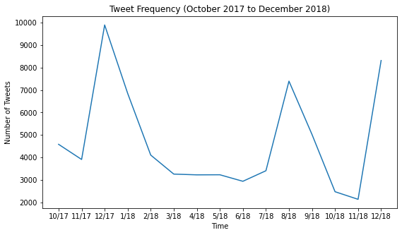

```python
# make a df of month/year and tweet counts
df = pd.DataFrame(columns = ['date', 'tweet_count'])
df['date'] = dates
df['tweet_count'] = count

# visualize the df  with sns
dims = (9, 5)
fig, ax = plt.subplots(figsize=(9, 5))
plot = sns.lineplot(ax=ax, data=df, x=df['date'], y=df['tweet_count'])
plot = plot.set(title="Tweet Frequency (October 2017 to December 2018)",xlabel="Time",ylabel="Number of Tweets")
```

As you can see there were several time periods where the frequency of tweeting about climate was a bit higher than others. December 2017 is particularlly high so I will look into that more below. Though, we can see that for the most part, people tweet a good amount about climate throughout the year and there really isn't one obvious pattern that we can learn from this graph.

## Bag of Words and Word Clouds

First off, I will convert dataframes of tweets in to bags of words representations. What that basically means is I look at a set of tweets and then will make a matrix representation of these tweets as one. So every possible word in all the tweets will be the columns and the tweet ids will be my rows. Each row is a tweet. Every word in all the tweets gets a column. If tweet #10 has the word "java" 10 times then it will have a ten in its "java" column, if it has "cowgirl" 0 times then it will have a 0 the "cowgirl" column. Most cells will be 0 because there are LOTS of columns but only so many words one uses in any single tweet. I will then use these bags of words to make word clouds which will represent the bag of words with words on an image where the more a word is used, the bigger it is. You may find this explanation of bag of words a bit more helpful so feel free to check it out for clarification: https://en.wikipedia.org/wiki/Bag-of-words_model.

```python
# These were the terms used for collecting tweets, terms with space have been made into two elements and duplicates
# are remoevd. Search criteria that was multiple words have been split in to two or more words.
# The final one amp, is just HTML for "&" and so we do not want that in the visuals because its not a
# word and its not semantically meaningful
rm = ["climatechange", "climate", "change", "real", "act", "climate", "global", "warming", "hoax", "denier",
      "false", "not", "amp"]

# Object to vectorize words into a bag of words
cv=CountVectorizer(analyzer='word')

# add a column with the text of each tweet as one string (tokens merged together)
tweets = []
for r in data.iterrows():
    tweets.append(" ".join(r[1]["tokens"]))
data["tweet"] = tweets

# define a function that takes in a data frame of tweets and returns a bag of words w/ the help of sklearn
def make_bag_of_words(tweets):
    info = cv.fit_transform(tweets["tweet"])
    bow = pd.DataFrame(info.toarray(), columns=cv.get_feature_names())
    bow.drop(columns=rm, inplace=True)
    bow.index=tweets.index
    return bow

# make a bag of words for each year i have data on
bags = []
for i in range(2017,2020):
    bags.append(make_bag_of_words(data[data["year"] == i]))

seventeen = 0
eighteen = 1
nineteen = 2

# example output for 2018
bags[nineteen].head()
```

| tweetID | a_film_maker | a_joyful_cynic | aaaaahhhhh | aaaarrrggghhh | aaahhhh | aafp | aanthanurdc | aaronatfoe | aaronbastani | aaroncarpenter | ... | सभ | 𝒢𝓁𝑜𝒷𝒶𝓁 | 𝒲𝒶𝓇𝓂𝒾𝓃𝑔 | 𝒾𝓈𝓃 | 𝓇𝑒𝒶𝓁 | 𝗳𝗶𝗿𝗲 | 𝗶𝘀 | 𝗼𝗻 | 𝗽𝗹𝗮𝗻𝗲𝘁 | 𝘁𝗵𝗲 |
| --- | --- | --- | --- | --- | --- | --- | --- | --- | --- | --- | --- | --- | --- | --- | --- | --- | --- | --- | --- | --- | --- |
| 1129451400457543681 | 0 | 0 | 0 | 0 | 0 | 0 | 0 | 0 | 0 | 0 | ... | 0 | 0 | 0 | 0 | 0 | 0 | 0 | 0 | 0 | 0 |
| 1129451354920030208 | 0 | 0 | 0 | 0 | 0 | 0 | 0 | 0 | 0 | 0 | ... | 0 | 0 | 0 | 0 | 0 | 0 | 0 | 0 | 0 | 0 |
| 1129451429364502529 | 0 | 0 | 0 | 0 | 0 | 0 | 0 | 0 | 0 | 0 | ... | 0 | 0 | 0 | 0 | 0 | 0 | 0 | 0 | 0 | 0 |
| 1129451461426012160 | 0 | 0 | 0 | 0 | 0 | 0 | 0 | 0 | 0 | 0 | ... | 0 | 0 | 0 | 0 | 0 | 0 | 0 | 0 | 0 | 0 |
| 1129451476517085185 | 0 | 0 | 0 | 0 | 0 | 0 | 0 | 0 | 0 | 0 | ... | 0 | 0 | 0 | 0 | 0 | 0 | 0 | 0 | 0 | 0 |

5 rows × 22021 columns

Shockingly, you probably aren't getting much insight from looking at this massisve matrix of mostly 0s. So lets create a function to take that data and make it into a word cloud!

### Write a function that makes a word cloud, given a bag of words

```python
# I made a function that will display a word cloud give the word frequencies as a df
def make_word_cloud(freqs):
    # sum all rows of given df to dispaly data and display 50 words max
    wc = WordCloud(width=1000, height=800, max_words=50,colormap="Dark2").generate_from_frequencies(freqs.sum())
    plt.figure(figsize=(10,8))
    plt.imshow(wc)
    plt.axis("off") # don't show x and y axes
    plt.show()
```

```
2017 Climate Change Tweets
```

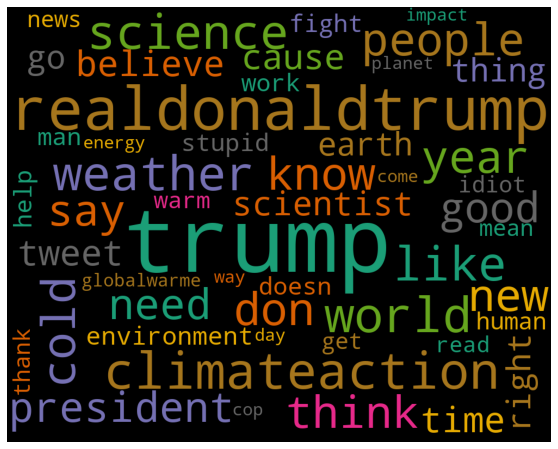

```python
print("2017 Climate Change Tweets")
make_word_cloud(bags[seventeen])
```

As you can see in 2017, President Trump was mentioned many times (not only in the traditional meaning but also his Twitter handle @realdonaldtrump). Another predominant term was climateaction which was used to call for action on climate. There are lots of words here that do not show us what the sentiment of the tweets are so we will have to wait and see for that.

```
2018 Climate Change Tweets
```

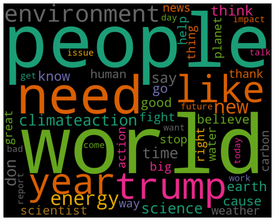

```python
print("2018 Climate Change Tweets")
make_word_cloud(bags[eighteen])
```

Words dominated like need, people, and world. To a lesser degree, enviroment as well. These words aren't ones with obvious sentiment without context. The words dominating cannot really tell us much of the content of the tweets here. Again, President Trump was a common word in the tweets.

```
2019 Climate Change Tweets
```

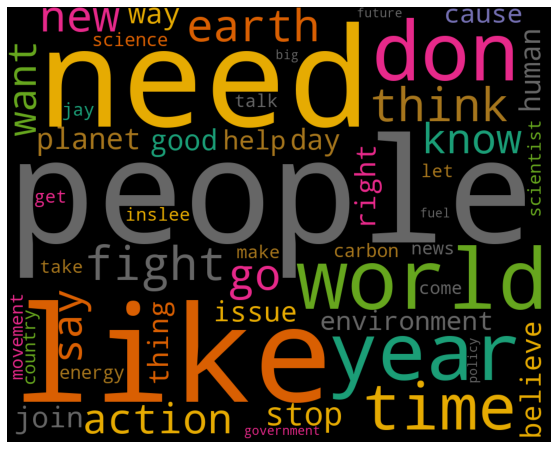

```python
print("2019 Climate Change Tweets")
make_word_cloud(bags[nineteen])
```

Many of the most used words are not really positive or negative towards climate. People and need are again predominant. Like could be used a vaiety of contexts so I cannot guess what context it was used in easily. When looking at this word cloud recall I have limited data for 2019.

### Most interacted with tweets

Here I will use the WordCloud library to visualize the 1,000 most interacted with tweets. I define an interaction as a favorite or retweet and I weighted them equally when I combined the two earlier.

```
Top 1,000 Most Interacted With Tweets
```

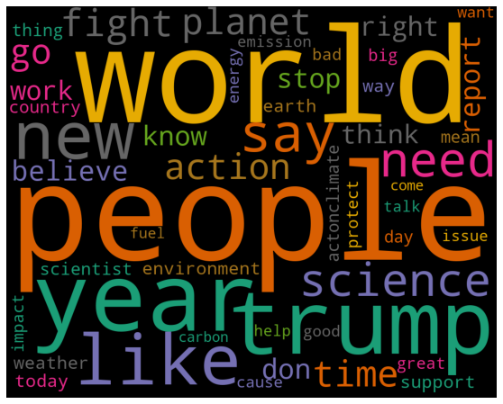

```python
# Make a word count of the most interacted with tweets (what got the most likes and retweets)
data = data.sort_values(by=["total_interactions"], ascending=False)
top_1000 = data.head(1000)
print("Top 1,000 Most Interacted With Tweets")
make_word_cloud(make_bag_of_words(top_1000))
```

It looks like the popular kids on Twitter are largely tweeting the same words as everyone else. Could be interesting later on to see if they have a different sentiment though?!

### The peek month of climate tweeting

Recall that it was 12/2017 where there was close to 10K sampled climate tweets for that month so what was everyone saying?

```
December 2017 Climate Change Tweets
```

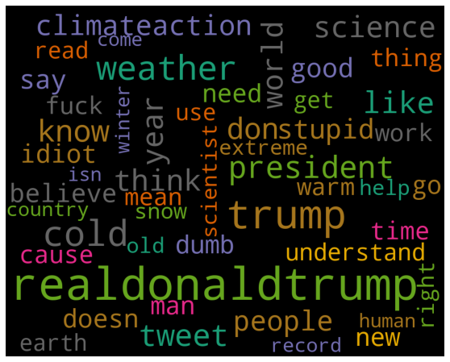

```python
twentyseventeen = data[data["year"] == 2017]
start = datetime.date(2017, 12, 1) # start of december
dec_2017 = twentyseventeen[twentyseventeen["date_tweeted"] >= start]
bow_12_17 = make_bag_of_words(dec_2017)
print("December 2017 Climate Change Tweets")
make_word_cloud(bow_12_17)
```

This month had many mentions of Trump, with him being the most common term. There was also lots of negative words that include the f word, dumb, and idiot. While curse words are often associated with negative sentiment, it is known that curse words do not always indicate this when talking about climate as many climate tweets are angry but also positive towards climate.

## Normalized Length of Tweet

Here when I say normalzied all I mean is that we are only looking at the string that contains text that is semantically meaningful i.e. not short words and very long words like I, you, this, that, supercalifragilisticexpialidocious, etc.

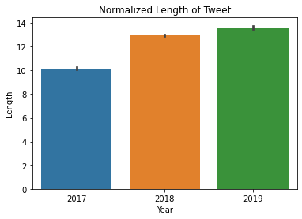

```python
# use lambda function to get length
data['tweet_length']=data['tokens'].apply(lambda tokens: len(tokens))

# plot the lengths for each each
plot = sns.barplot(x='year',y='tweet_length',data=data)
plot.set(title="Normalized Length of Tweet",xlabel="Year",ylabel="Length")

# go ahead the drop the tweet length so df is more readable/short width later on
data = data.drop(columns=["tweet_length"])
```

When looking at this graph one major thing to consider is that it may not be such a simple oh tweet length about climate must be going up year after year for a couple of reasons. One major factor is the sample from 2018 is much larger than the other two because the majority of data colleciton took place in 2018 and much of Jan-Apr 2019 lacked sampling. In 2019, GWU collected data the first week of January, not at all in Feb-Mar, the last two weeks of April, and most of May.

So roughly speaking we can say that tweet length may have increased when talking about tweets related to climate change but because of what I just said this is at best a rough guess because we aren't really seeing massive changes in length for example between 2018 and 2019.

## Are we just seeing a few dominant voices on Twitter?

Lets look at a distribution of who is tweeting to see if its a few dominant voices or the masses crying on Twitter.

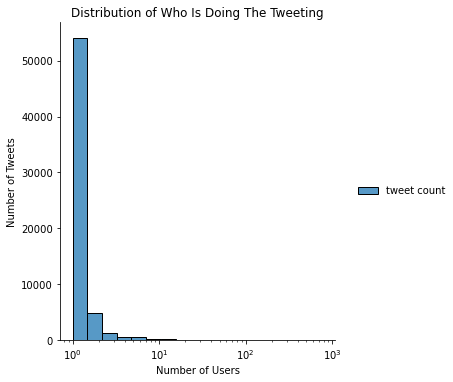

```python
# set of tweeters
tweeters = list(set(data["tweeter"]))
times_tweeted = dict.fromkeys(tweeters , 0)

# Calculate how many times each tweeter has tweeted
for r in data.iterrows():
    row = r[1]
    user = row["tweeter"]
    times_tweeted[user] += 1

# get key and values as lists
users = list(times_tweeted.keys())
counts = list(times_tweeted.values())

# put them in a dataframe
df = pd.DataFrame(columns = ['user', 'tweet count'])
df["user"] = users
df["tweet count"] = counts

# plot the distribution using displot in sns
plot = sns.displot(df, log_scale=True)
plot.set(title="Distribution of Who Is Doing The Tweeting", ylabel="Number of Tweets", xlabel="Number of Users")
```

Nearly every person in the data set has tweeted around a couple times about climate. This plot is very skewed (right). So we are NOT just seeing a few voiced but many voices on climate!

NOTE: This graph is using a logarithmic scale.

# Sentiment Analysis and Machine Learning

For this section I will do sentiment analysis with a pretrained model from VADER and use those results in my machine learning when doing classification with multiple classification algorithms (Naive Bayes, Random Forest, SVM). I will give a brief introduction to what sentiment analysis is but if you are interesting in learning more, I would reccommend that you check out these links that dive deeper and may explain it a bit better: https://towardsdatascience.com/sentiment-analysis-concept-analysis-and-applications-6c94d6f58c17, https://monkeylearn.com/sentiment-analysis/.

So what is sentiment analysis? On a basic level its looking at the words used in a piece of text like "Climate change is my favorite thing to tweet about 😍." and seeing if the text is neutral, positive, or negative. This example would likely be said to have positive sentiment based on the word favorite and the emoji if that was considered in the calculation.

Something to conisder here: ["U.S. adult Twitter users are younger and more likely to be Democrats than the general public"](https://www.pewresearch.org/internet/2019/04/24/sizing-up-twitter-users/). So while we may see more positive tweets below that does not imply that this is reflective of all sentiment outside Twitter. It is important to remember this because what we analyze on Twitter is based on who tweets and that does not reflect all people. Also recall, all tweets are English so it is mostly Americans tweeting because [the US dominates on Twitter in terms of users](https://www.statista.com/statistics/242606/number-of-active-twitter-users-in-selected-countries/).

## Sentiment Analysis

### Assign each tweet an overall sentiment score

Here I am using VADER and its compound sentiment analysis scoring. The compound score combines the fraction of its neutral, positive, and negative sentiment into one sentiment score. The compound score will be between -1 (very negative) and +1 (very positive). You can read more about this in the read me of their repository on GitHub [here](https://github.com/cjhutto/vaderSentiment#about-the-scoring). According to this [article](https://neptune.ai/blog/sentiment-analysis-python-textblob-vs-vader-vs-flair), VADER is ideal for analyzing sentiment on social media data and gets good results when using this sort of data. I orginally intended to use TextBlob but this article convinced me that VADER was my best option to use for social data.

```python
analyzer = SentimentIntensityAnalyzer()
sentiment_values = []

for r in data.iterrows():
    tweet = r[1]["tweet"]
    # returns the degree to which its positive/negative/netural and a compound score combining all of those
    scores = analyzer.polarity_scores(tweet)
    # store the compound score
    compound = scores["compound"]
    sentiment_values.append(compound)

data["sentiment_scores"] = sentiment_values
```

### Label each tweet as positive, negative, or neutral in sentiment depending on value just assinged

I will use the guidlines for deciding if a tweet is positive/negative/neutral layed out by VADER here: https://github.com/cjhutto/vaderSentiment#about-the-scoring.

```python
sentiment_label = []

POSITIVE = 1
NEGATIVE = -1
NEUTRAL = 0

for val in sentiment_values:
    #positive sentiment: compound score >= 0.05
    if val >= 0.05:
        sentiment_label.append(POSITIVE)
    #neutral sentiment: (compound score > -0.05) and (compound score < 0.05)
    elif (val > -0.05) and (val < .05):
        sentiment_label.append(NEUTRAL)
    #negative sentiment: compound score <= -0.05
    elif val <= -0.05:
        sentiment_label.append(NEGATIVE)

data["sentiment_label"] = sentiment_label
data.head()
```

| tweetID | tweeter | total_interactions | date_tweeted | tokens | year | tweet | sentiment_scores | sentiment_label |
| --- | --- | --- | --- | --- | --- | --- | --- | --- |
| 1125876811001487365 | emilyvmna | 494755 | 2019-05-07 | [year, meet, gala, climate, change, themed, sa... | 2019 | year meet gala climate change themed save plan... | 0.7506 | 1 |
| 1124432884599787521 | IlhanMN | 121308 | 2019-05-03 | [woman, color, hear, instead, disagree, doesn,... | 2019 | woman color hear instead disagree doesn know t... | -0.5719 | -1 |
| 946553250203013120 | danwlin | 62632 | 2017-12-29 | [east, currently, nighttime, bad, scientist, s... | 2017 | east currently nighttime bad scientist spend t... | -0.3182 | -1 |
| 961740406223355904 | goodoldcatchy | 54385 | 2018-02-08 | [jesus, wasn, white, trump, isn, christian, tr... | 2018 | jesus wasn white trump isn christian trickle e... | 0.2732 | 1 |
| 1123675465774981120 | GretaThunberg | 32990 | 2019-05-01 | [mps, pass, motion, make, uk, parliament, worl... | 2019 | mps pass motion make uk parliament world decla... | 0.1779 | 1 |

### Let's look at the sentiment distribution across the data

First off I will look at all data and the distribution of sentiment for all tweets and then I will look at the top 1000 most interacted with tweets.

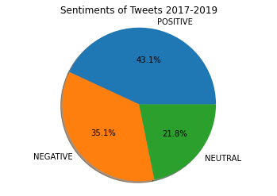

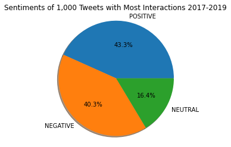

```python
# A function to pie graph the sentiment of the tweets in a data frame, takes in a df and a graph title
def graph_sentiment(df, title):
    labels = 'POSITIVE', 'NEGATIVE', 'NEUTRAL'
    sizes = [len(df[df["sentiment_label"] == POSITIVE].index), len(df[df["sentiment_label"] == NEGATIVE].index),
         len(df[df["sentiment_label"] == NEUTRAL].index)]
    fig1, ax1 = plt.subplots()
    ax1.pie(sizes, labels=labels,autopct='%1.1f%%',shadow=True)
    plt.title(label=title)
    ax1.axis('equal')
    plt.show()

# Plot all tweets' sentiment
graph_sentiment(data,"Sentiments of Tweets 2017-2019")

# Lets look at sentiment of the top 1000 tweets compared to the overall
top_1000 = data.sort_values(by=["total_interactions"], ascending=False).head(1000)
graph_sentiment(top_1000,"Sentiments of 1,000 Tweets with Most Interactions 2017-2019")
```

So a couple of things are going on here. Looking at all the data, most tweets are positive in sentiment towards climate change but its no majority! Also, a fair amount of tweets are labeled as neutral but its about half as many compared with the positive sentiment tweets. Recall I used a pretrained model though so it will NOT be perfect in any way when looking at tweets about climate when deciding its sentiment. Though, VADER is ideal for social network data so this is sort of the best option for a pretrained model in my case.

In regards to the bottom graph that looked at the top 1,000 most interacted with tweets (i.e. sum of retweets and favorites), they were a good bit more negative than the full data set by about 5% and they were less neutral. Though, the positive percentage is basically the same for all tweets and the most interacted with ones. One could may make an assumption that more polarzing or negative tweets are more negative but I am not sure we have the full evidence for that here since this was a pretrained model. Though I think we could make an educated guess that it may be the case that more negative tweets get more attention than neutral tweets. This is what one should expect with a polarizing topic online. I just would be hesitant to call this a causation without further analysis on this.

### Looking for trends in sentiment over time

I will only look at months for which I have continous data. By this I mean 10/2017-12/2018, I used these dates earlier to make the dictionary that I used for the frequency of tweets over time graph.

```python
# Recall what month/year pairs we will be looking at now
list(tweets_per_month.keys())
```

```
[(10, 2017),
 (11, 2017),
 (12, 2017),
 (1, 2018),
 (2, 2018),
 (3, 2018),
 (4, 2018),
 (5, 2018),
 (6, 2018),
 (7, 2018),
 (8, 2018),
 (9, 2018),
 (10, 2018),
 (11, 2018),
 (12, 2018)]
```

```python
# Seperate the data into month dfs
seventeen = data[data["year"] == 2017]

# start dates of 2017 months
oct2017_start = datetime.date(2017, 10, 1)
nov2017_start = datetime.date(2017, 11, 1)
dec2017_start =  datetime.date(2017, 12, 1)

# data frames for 2017
oct2017 = seventeen[seventeen["date_tweeted"] >= oct2017_start]
oct2017= oct2017[oct2017["date_tweeted"] < nov2017_start]

nov2017 = seventeen[seventeen["date_tweeted"] >= nov2017_start]
nov2017 = seventeen[seventeen["date_tweeted"] < dec2017_start]

# only one line as no months in 2017 after dec
dec2017 = seventeen[seventeen["date_tweeted"] >= dec2017_start]

# list of dfs for each month
dataframes = [oct2017, nov2017, dec2017]

eighteen = data[data["year"] == 2018]

# make df for each month of 2018 and append to list
for i in range(1,13):
    curr_month_start = datetime.date(2018, i, 1)
    curr_month = eighteen[eighteen["date_tweeted"] >= curr_month_start]
    # if not dec then cuttoff the rest of the year curr month has now
    if i != 12:
        curr_month = curr_month[curr_month["date_tweeted"] < datetime.date(2018, i+1, 1)]
    # append the df to the list of frames
    dataframes.append(curr_month)

# stores fraction that is that sentiment in each month
pos = []
neg = []
neu = []

# for each data frame calculate fraction that is that sentiment
for df in dataframes:
    total = len(df)
    pos.append(len(df[df["sentiment_label"] == POSITIVE].index)/total)
    neg.append(len(df[df["sentiment_label"] == NEGATIVE].index)/total)
    neu.append(len(df[df["sentiment_label"] == NEUTRAL].index)/total)

# indicies are dates
indicies = ["10/17","11/17", "12/17"]
# add 2018 months
for i in range(1,13):
    indicies.append(str(i)+"/"+"18")

# build a df
df = pd.DataFrame(list(zip(indicies, pos, neg, neu)),
                  columns =["Month", 'Positive proportion', 'Negative proportion', "Neutral proportion"])
df.set_index('Month', inplace=True)
df
```

| Month | Positive proportion | Negative proportion | Neutral proportion |
| --- | --- | --- | --- |
| 10/17 | 0.377317 | 0.344384 | 0.278299 |
| 11/17 | 0.408557 | 0.325713 | 0.265730 |
| 12/17 | 0.394463 | 0.396080 | 0.209457 |
| 1/18 | 0.435182 | 0.330073 | 0.234745 |
| 2/18 | 0.458841 | 0.336337 | 0.204822 |
| 3/18 | 0.462577 | 0.290491 | 0.246933 |
| 4/18 | 0.455363 | 0.327030 | 0.217607 |
| 5/18 | 0.462848 | 0.321053 | 0.216099 |
| 6/18 | 0.463605 | 0.312925 | 0.223469 |
| 7/18 | 0.442945 | 0.346729 | 0.210326 |
| 8/18 | 0.419551 | 0.373175 | 0.207274 |
| 9/18 | 0.452319 | 0.342226 | 0.205455 |
| 10/18 | 0.425687 | 0.383683 | 0.190630 |
| 11/18 | 0.389331 | 0.368273 | 0.242396 |
| 12/18 | 0.434396 | 0.359711 | 0.205893 |

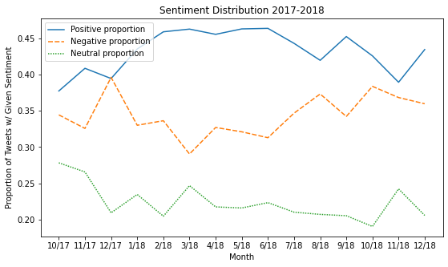

```python
# plot it with seaborn
dims = (9, 5)
fig, ax = plt.subplots(figsize=(9, 5))
plot = sns.lineplot(ax=ax,data=df)
plot.set(title="Sentiment Distribution 2017-2018", ylabel="Proportion of Tweets w/ Given Sentiment")
plot
```

For the proportion of tweets that are positive, after 12/2017, the proportion of positive tweets goes up and stays very stable until 8/2018. Overall there is not a major change from 10/17 to 12/18 in this proportion.

For the negative line, it goes up in 12/2017 (recall thats the time with the most tweets) and drops over the next 3 months and then gets close to back where it was over the course of 2018. This proportion also does not change dramatically in the long run though it does change by 10% in 3 months at one point which is pretty interesting. This means that over 3 months there was 10% less negative tweets about climate change but it all goes back up (though not all the way) over time. I will discus possible causes in more depth later that could include extreme weather.

For the neutral line, nothing much of interest happens. It more or less does not change. This proportion sort of zip zags in the start and then is pretty stable for most of 2018.

So in summary, we saw one major shift in early 2018 where positivity rose, negativity lessened, and there was no clear trend then in neutrality.

## Machine Learning

I will be following this tutorial on how to work with text data and do ML with it: https://scikit-learn.org/stable/tutorial/text_analytics/working_with_text_data.html.

### Designate training data and tranform documents into feature vectors

Here we will transform documents (tweets) into feature vectors where a vector for a tweet contains the number of times each word is used. Its a dictionary of word to word count. You can find the count vectorizer documentation here: https://scikit-learn.org/stable/modules/generated/sklearn.feature_extraction.text.CountVectorizer.html.

```python
# Transform the documents to feature vectors
count_vect = CountVectorizer()
# Train with 80% of the data
training_data = data.sample(frac=8/10)

# Learns vocab used in training tweets, returns document term matrix,
# same as fitting then transforming but slightly more efficent
X_train_counts = count_vect.fit_transform(training_data["tweet"])

# Test it out with a common word in the data set
print("The word climate is used", count_vect.vocabulary_.get(u'climate'), "times in all the training tweets.")
```

[output not shown]

### TF-IDF

Here we will use our results from before to transform those results into TD-IDF form. This is a way of creating a matrix of our training data like a bag of words I described before. Though with TD-IDF it accounts for document size in word occurences so that it is weighted properly relative to documents size. You can find a more nuanced and mathematical explanation here: https://en.wikipedia.org/wiki/Tf–idf.

```python
# fit estimator to data
tfidf_transformer = TfidfTransformer(use_idf=True).fit(X_train_counts)
# transform the count matrix into a tf-idf representation
X_train_tfidf = tfidf_transformer.transform(X_train_counts)
print("The shape of the the TF-IDF matrix is",X_train_tfidf.shape)
```

```
The shape of the the TF-IDF matrix is (66899, 67059)
```

### Naive Bayes Classifier

I chose this algorithm which utilizes Bayes Theorem because its a good starting point for text classification. Bayes is used to determine if the chance that the document (tweet) is more likely to be (in this case) neutral, negative, or postive. I used multinominal naive Bayes for this classification since we are dealing with a non-binary classification.

Here are a few references on Naive Bayes that were helpful for me. The Stanford one goes into more in depth in terms of applications of this technqiue and the part on Naive Bayes starts a few slides in. https://web.stanford.edu/class/cs124/lec/naivebayes.pdf, https://medium.com/analytics-vidhya/naive-bayes-classifier-for-text-classification-556fabaf252b, https://scikit-learn.org/stable/modules/naive_bayes.html#naive-bayes

```python
# Build a df of test data (20% of data df)
df = data.copy().drop(training_data.index)
X_test= df["tweet"]
y_test = df["sentiment_label"]

# Train the classifier
clf = MultinomialNB().fit(X_train_tfidf, training_data["sentiment_label"])

X_new_counts = count_vect.transform(X_test)
X_new_tfidf = tfidf_transformer.transform(X_new_counts)
y_pred_test = clf.predict(X_new_tfidf)
```

```python
# function to Print the first 10 predicted sentiments with the corresponding tweet
def print_predictions(X_test, predicted):
    for (tweet, sentiment) in zip(X_test[:10], predicted[:10]):
        result = ""
        # matche the sentiment integer to its meaning
        if sentiment == POSITIVE:
            result += "Positive: "
        elif sentiment == NEGATIVE:
            result += "Negative: "

        elif sentiment == NEUTRAL:
            result += "Neutral: "
        result += tweet + "\n"
        print(result)
```

```python
print_predictions(X_test, y_pred_test)
```

```
Negative: woman color hear instead disagree doesn know talk feel small administration think climate change chinese hoax

Negative: jesus wasn white trump isn christian trickle economics doesn work border wall isn feasible climate change threat don need nuke legal abortion save live obama bear un important stormy daniel

Negative: mps pass motion make uk parliament world declare environment climate emergency historic hopeful news nation follow word turn immediate action

Positive: summer tad bit hot guy chill co emission global warming suck

Negative: believe don care climate change trash environment war monger deplete resource think get zap fact want bad think rapture happen soon

Positive: mom bowl strike world great bowler strike prove

Negative: think people people think know carbon tax scam power grab scheme base bogus claim peddle conman like algore

Positive: malcolm turnbull say wouldn lead government didn strong policy climate change lead hasn get policy today event geoff cousin pm abcnews local radio pm auspol

Positive: people ask haven write column ipcc report answer ve write column climate change approach imaginable angle write new

Negative: barackobama tweets day climate change tweet terror attack muslim maniacs kill hundred people easter thank god day white house will admit mean stain usa feel
```

```python
naive_bayes_score = accuracy_score(y_test, y_pred_test)
print("The Naive Bayes' predictions are accurate",int(naive_bayes_score *100), "percent of the time")
```

```
The Naive Bayes' predictions are accurate 69 percent of the time
```

That is not too bad but not great by any means. It is a quick prediction time though. This is partly because I am using a pretty simple learner and not optimizing it very much. I would like to see if we can do any better. Next I will be trying this same classification problem out with a random forest classification, into the woods we go!

### Random Forest Classification

From this point on I am not going to explicity do each step like I do for the Naive Bayes. Instead I will use the pipline class to let sklearn know that I want to use count vectorizering, td-idf, and then let it know the classifier I want to use.

I chose to try out random forest classification because its a simple to understand but very powerful ensemble method in machine learning. It basically has many different decesion trees and they vote on the outcome. It is an easy to understand method for classification. By default it uses 100 trees and they have no max depth. You can learn more about decesion trees and random forests in these articles: https://en.wikipedia.org/wiki/Random_forest, https://towardsdatascience.com/understanding-random-forest-58381e0602d2. I referenced this tutorial on evaluating random forests: https://medium.com/analytics-vidhya/evaluating-a-random-forest-model-9d165595ad56.

```python
# use sklearn's Pipline class to classify tweets with a random forest and use same methods as before
text_clf = Pipeline([
     ('vect', CountVectorizer()),
     ('tfidf', TfidfTransformer()),
     ('clf', RandomForestClassifier()),
 ])
text_clf.fit(training_data["tweet"], training_data["sentiment_label"])
y_pred_test = text_clf.predict(X_test)
```

```python
print_predictions(X_test, y_pred_test)
```

```
Negative: woman color hear instead disagree doesn know talk feel small administration think climate change chinese hoax

Positive: jesus wasn white trump isn christian trickle economics doesn work border wall isn feasible climate change threat don need nuke legal abortion save live obama bear un important stormy daniel

Negative: mps pass motion make uk parliament world declare environment climate emergency historic hopeful news nation follow word turn immediate action

Positive: summer tad bit hot guy chill co emission global warming suck

Negative: believe don care climate change trash environment war monger deplete resource think get zap fact want bad think rapture happen soon

Positive: mom bowl strike world great bowler strike prove

Positive: think people people think know carbon tax scam power grab scheme base bogus claim peddle conman like algore

Positive: malcolm turnbull say wouldn lead government didn strong policy climate change lead hasn get policy today event geoff cousin pm abcnews local radio pm auspol

Negative: people ask haven write column ipcc report answer ve write column climate change approach imaginable angle write new

Negative: barackobama tweets day climate change tweet terror attack muslim maniacs kill hundred people easter thank god day white house will admit mean stain usa feel
```

```python
forest_accuracy = accuracy_score(y_test, y_pred_test)
print("The random forest has an accuracy score of", forest_accuracy)
```

```
The random forest has an accuracy score of 0.8604484304932736
```

This is 17% more accurate of a prediction! Though sklearn does not reccomend Random Forest Classifiers for text to start off, it can still be used and concepetually is pretty simple and can do an even better job than Naive Bayes. This can still be improved on likely though. One of the best options for text classification is SVM so that is what we will try out next.

### Support Vector Machines (SVM)

Here I will be using SVM in the form of SVC which works for a non-binary classification problems like this. This is the conceptually hardest ML algorithm I will use but has the best predictions. At a basic level SVM works by trying to find the best line or hyperplane that seperates the categories of data and it also uses some fancy tricks that are explained in the Monkeylearn article below.

You can find the pros and cons of SVM, as well as some info on SVC and the general technique here: https://scikit-learn.org/stable/modules/svm.html and an article on SVM here that is a good explainer: https://monkeylearn.com/blog/introduction-to-support-vector-machines-svm/.

```python
text_clf = Pipeline([
     ('vect', CountVectorizer()),
     ('tfidf', TfidfTransformer()),
     ('clf', SVC()),
 ])
text_clf.fit(training_data["tweet"], training_data["sentiment_label"])
y_pred_test = text_clf.predict(X_test)
```

```python
svm_score = accuracy_score(y_test, y_pred_test)
percent = int(svm_score * 100)
print("SVM is correct in predicting sentiment labels", percent, "percent of the time.")
```

```
SVM is correct in predicting sentiment labels 90 percent of the time.
```

This is great, we are now getting it right 9/10 times, a sligth improvement from Random Forests! I don't think I will get much better than this but this is a good improvement. The real drawback though is that SVM can take a while to run and is a tad more complex to understand. Forests and their democracy are just so simple and quick but SVM does a slight better job in prediction accuracy.

### How do the classifiers stack up?

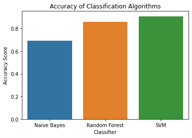

```python
# Graphically compare the performance of the classifiers
# assemble scores
learners = ['Naive Bayes', 'Random Forest', 'SVM']
scores = [naive_bayes_score,forest_accuracy,svm_score]
df = pd.DataFrame(list(zip(learners,scores)),columns =["learners", "scores"])
# plot
plot = sns.barplot(data=df, x="learners",y="scores")
plot.set(title="Accuracy of Classification Algorithms",xlabel="Classifier",ylabel="Accuracy Score")
plot
```

From this plot, we see that Naive Bayes does the worst and is not too great when compared with Random Forest Classification and SVM. I did not gain much accuracy from using SVM even though SVM took like a long time to run. I think the random forest and SVM predictions were very solid and would not expect to be able to get that good predictions with so little code.

# Insight and Conclusions

I will be wrapping up by bringing together what I learned from this analysis.

1) The most popular tweets are all saying the same things that the average person's tweets say. The word cloud for the top 1000 most interacted with tweets showed that the words the most known faces on Twitter are not using language different from you and I. Their sentiment is not even that different though I address this some some below. (See BOW and Wordclouds section.)

2) The majority of the tweets about climate come not from a few people but from the masses. We saw this in the last plot right before sentiment analysis and ML. Nearly every tweeter tweets very little about climate change and only a few select people tweet about climate in high volume. (See Are we just seeing a few dominant voices on Twitter?)

3) There is not an overwheling majority of tweets that go positive or negative. No category of neutral/positive/negative is a majority of tweets based on our sample. The closest we got to a majority was 43% of tweets being positive. (See Sentiment Analysis section.)

4) To some degree, the most popular tweets are more polarizing (as in less neutral) than when looking at all tweets. The popular tweets were 5% more negative than all the data and 5% less neutral. This was not a real suprise to me but it was interesting that this is there are lots of neutral tweets that are still very much liked and retweeted. (See Sentiment Analysis section.)

5) The proportion of tweets that have any given sentiment had few changes over 2017-2018 (see Sentiment Distribution 2017-2018). There is a noticable shift in the proportion of negative tweets downards in early 2018 by 10% but otherwise there really are not any major shifts. At this time the positive proportion went up and neutrality had no clear trend. These shifts correct over time more or less. After looking at the a [summary of 2018 in climate change by the Washington Post](https://www.washingtonpost.com/weather/2018/12/31/five-most-extreme-weather-events-united-states/), one possible cause could have been extreme winter weather in the US during early 2018 but we have no evidence to call this causation. It could be that positivity and neutrality were just drowing the negativity out. At the moment I have only noticed a correlation with extreme winter and lower amounts of negative tweets about climate change. One of the goals was to see if we could find major shifts in sentiment over time. We found one trend in early 2018 but no long term trends.

6) There are several reasons why we could have not found long term shifts in sentiment. One, there is no longer term changes to find. Two, the pretrained sentiment analyzer was not up to the task of understanding climate change tweets. Three, we could have used too small a sample. Four, we needed to look at a longer time frame. Five, it may have been some other flaw in how I chose to analyze the information I collected.

# Acknowledgements

Thank you so much for taking your time to read this analysis!

I would like to thank the George Washington University's TweetSets organization for their data set on climate change on Twitter. Their data and website to sample the data set made this project so much easier. Once again all of their data sets from Twitter can be found right [here](https://tweetsets.library.gwu.edu).

I would also like to thank University of Maryland Professor John Dickerson and the CMSC320 instructional staff for their help and advice while working on this project.